# [주제] 원유 가격 상승이 국내 기업들에 미친 영향을 알아보고 분석한다.

### [서론]

· 전 세계가 코로나 19의 공포에서 회복되며 원유 수요가 급증한 한편, 러시아의 우크라이나 침공으로 미국의 러시아산 원유 수입 금지령과 더불어 원유 공급이 부족해질 것이라는 공포감의 확산은 원유 가격의 폭등으로 이어지게 되었다.  
· 따라서 이러한 유가폭등이 국내 기업들에게 미친 영향을 알아보고 국내산업이 나아가야할 방향성을 제시한다.

### [목차]

(1) 국제 유가 변동 분석  
(2) 국내 유가 변동 분석  
(3) OCED회원국 원유 의존도 분석  
(4) 원유 가격 상승에 대한 악영향을 받은 국내 기업 분석  
(5) 원유 가격 상승에 대한 긍정적 영향을 받은 국내 기업 분석  
(6) 최종 정리  
(7) 데이터 출처

```python
# 모듈 삽입
import pandas as pd
import numpy as np
import matplotlib.pyplot as plt
import platform
import matplotlib
matplotlib.rcParams['axes.unicode_minus'] = False

# Data 관련 변수 선언
DIR_PATH = r'./data/'
```

## (1) 국제 유가 변동 분석

```python
# 국제 석유제품 가격 data 읽어오기 및 dataframe확인
oilDF = pd.read_csv(DIR_PATH+'2020.01~2022.07 국제 석유제품가격(월간).csv', encoding='euc-kr')
oilDF.head()
```

|  | 기간 | 휘발유(92RON) | 등유 | 경유(0.05%) | 나프타 |
| --- | --- | --- | --- | --- | --- |
| 0 | 20년01월 | 69.12 | 75.40 | 76.06 | 60.88 |
| 1 | 20년02월 | 62.57 | 63.05 | 64.67 | 52.33 |
| 2 | 20년03월 | 35.19 | 39.32 | 44.46 | 30.28 |
| 3 | 20년04월 | 19.45 | 21.26 | 28.75 | 17.31 |
| 4 | 20년05월 | 30.83 | 28.89 | 33.97 | 26.31 |

```python
# 데이터 전처리    * 재사용 할 일이 없기때문에 inplace=True로 설정
# (1) '기간' column 인덱스로 설정
oilDF.set_index('기간', inplace=True)

# (2) 필요없는 column인 '나프타' 삭제
oilDF.drop('나프타', axis=1, inplace=True)

# (3) column명 재설정
oilDF.rename(columns={'휘발유(92RON)':'휘발유','경유(0.05%)':'경유'}, inplace=True)

# (4) dataframe 확인
oilDF.head()
```

| 기간 | 휘발유 | 등유 | 경유 |
| --- | --- | --- | --- |
| 20년01월 | 69.12 | 75.40 | 76.06 |
| 20년02월 | 62.57 | 63.05 | 64.67 |
| 20년03월 | 35.19 | 39.32 | 44.46 |
| 20년04월 | 19.45 | 21.26 | 28.75 |
| 20년05월 | 30.83 | 28.89 | 33.97 |

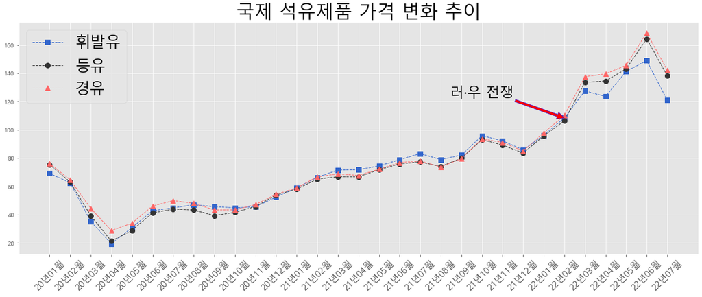

```python
# 국제 유가 변동현황 그래프로 시각화
# (1) '기간' index를 x축으로 사용하기 위해 list화
x = oilDF.index.to_list()

# (2) 각각의 column들을 y축으로 사용하기 위해 list화
y_1 = oilDF['휘발유'].to_list()
y_2 = oilDF['등유'].to_list()
y_3 = oilDF['경유'].to_list()

# (3) 그래프로 시각화
if platform.system() == 'Windows':
    plt.rc('font', family='Malgun Gothic')
else:
    plt.rc('font', family='AppleGothic')
plt.figure(figsize=(20,7))
plt.title('국제 석유제품 가격 변화 추이', size=30)
colors = ['#3366CC','#333333','#FF6666']
plt.plot(x,y_1, color=colors[0], label='휘발유', marker='s', markersize=8, linestyle='--', linewidth=1.0)
plt.plot(x,y_2, color=colors[1], label='등유', marker='o', markersize=8, linestyle='--', linewidth=1.0)
plt.plot(x,y_3, color=colors[2], label='경유', marker='^', markersize=8, linestyle='--', linewidth=1.0)
plt.xticks(ticks=x, labels=x, rotation=45, size=15)
plt.legend(fontsize=25)
plt.annotate('러·우 전쟁', ha = 'center', va = 'bottom', xytext = (x[21],y_1[30]), xy = (x[25], y_1[25]),
arrowprops = { 'facecolor' : 'r', 'edgecolor':'b', 'shrink' : 1}, size=23)
plt.style.use('ggplot')
plt.show()
```

### 분석 : 20년 04월 이후 꾸준한 상승세를 보이며, 22년 6월에 모든 유류 최고치를 찍음

## (2) 국내 시장 유가 변동 분석

```python
# 국내 석유제품 가격 data 읽어오기 및 dataframe확인
domestic_oilDF = pd.read_csv(DIR_PATH+'2020.01~2022.07 주유소 가격(월간).csv', encoding='euc-kr')
domestic_oilDF.head()
```

|  | 구분 | 보통휘발유 | 자동차용경유 | 실내등유 |
| --- | --- | --- | --- | --- |
| 0 | 2020년01월 | 1568.44 | 1398.40 | 975.31 |
| 1 | 2020년02월 | 1545.29 | 1369.85 | 967.82 |
| 2 | 2020년03월 | 1469.06 | 1280.77 | 933.10 |
| 3 | 2020년04월 | 1323.66 | 1132.44 | 857.98 |
| 4 | 2020년05월 | 1255.08 | 1065.79 | 796.46 |

```python
# 데이터 전처리
# (1) '구분' column 인덱스로 설정
domestic_oilDF.set_index('구분', inplace=True)

# (2) '구분' index 문자열 재설정 ex) 2020년1월 => 20년1월
domestic_oilDF.index = domestic_oilDF.index.str[2:]

# (3) column명 재설정
domestic_oilDF.rename(columns={'보통휘발유':'휘발유','자동차용경유':'경유','실내등유':'등유'}, inplace=True)

# (4) dataframe 확인
domestic_oilDF.head()
```

| 구분 | 휘발유 | 경유 | 등유 |
| --- | --- | --- | --- |
| 20년01월 | 1568.44 | 1398.40 | 975.31 |
| 20년02월 | 1545.29 | 1369.85 | 967.82 |
| 20년03월 | 1469.06 | 1280.77 | 933.10 |
| 20년04월 | 1323.66 | 1132.44 | 857.98 |
| 20년05월 | 1255.08 | 1065.79 | 796.46 |

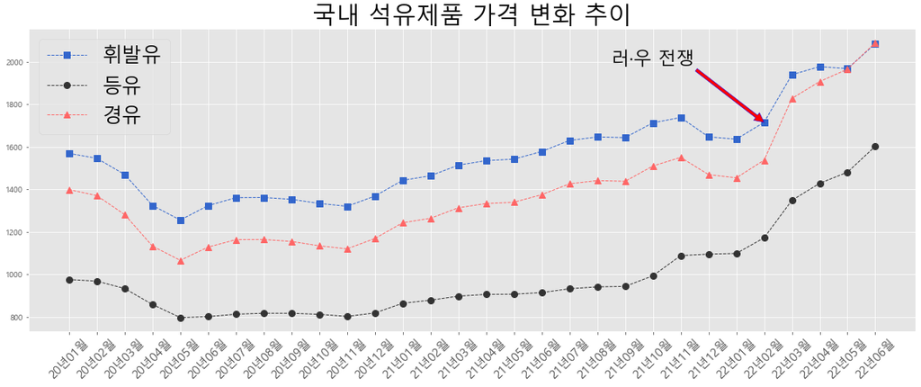

```python
# 국제 유가 변동현황 그래프로 시각화
# (1) '기간' index를 x축으로 사용하기 위해 list화
x = domestic_oilDF.index.to_list()

# (2) 각각의 column들을 y축으로 사용하기 위해 list화
y_1 = domestic_oilDF['휘발유'].to_list()
y_2 = domestic_oilDF['등유'].to_list()
y_3 = domestic_oilDF['경유'].to_list()

# (3) 그래프로 시각화
if platform.system() == 'Windows':
    plt.rc('font', family='Malgun Gothic')
else:
    plt.rc('font', family='AppleGothic')
plt.figure(figsize=(20,7))
plt.title('국내 석유제품 가격 변화 추이', size=30)
colors = ['#3366CC','#333333','#FF6666']
plt.plot(x,y_1, color=colors[0], label='휘발유', marker='s', markersize=8, linestyle='--', linewidth=1.0)
plt.plot(x,y_2, color=colors[1], label='등유', marker='o', markersize=8, linestyle='--', linewidth=1.0)
plt.plot(x,y_3, color=colors[2], label='경유', marker='^', markersize=8, linestyle='--', linewidth=1.0)
plt.xticks(ticks=x, labels=x, rotation=45, size=15)
plt.style.use('ggplot')
plt.annotate('러·우 전쟁', ha = 'center', va = 'bottom', xytext = (x[21],y_1[28]), xy = (x[25], y_1[25]),
arrowprops = { 'facecolor' : 'r', 'edgecolor':'b', 'shrink' : 1}, size=23)
plt.legend(fontsize=25)
plt.show()
```

### 분석 : 국제 유가와 마찬가지로, 22년 6월에 모든 유류 최고치를 찍음

## (3) 2020 OECD회원국 원유 의존도 분석

```python
# 원유 의존도 data 읽어오기 및 dataframe확인
oil_DependenceDF = pd.read_csv(DIR_PATH+'OECD회원국 원유의존도.csv', header=1)
oil_DependenceDF.head()
```

|  | 국가 | GDP(10억 달러) | 일 원유소비량(1,000배럴/일) | 원유의존도(배럴/GDP만달러) |
| --- | --- | --- | --- | --- |
| 0 | 한국 | 1638 | 2560 | 5.70 |
| 1 | 캐나다 | 1644 | 2282 | 5.07 |
| 2 | 칠레 | 253 | 347 | 5.00 |
| 3 | 그리스 | 189 | 244 | 4.70 |
| 4 | 터키 | 720 | 903 | 4.58 |

```python
# 데이터 전처리
# (1) '국가' column => index로 설정
oil_DependenceDF.set_index('국가', inplace=True)

# (2) '원유의존도' column을 기준으로 오름차순 정렬
oil_DependenceDF.sort_values('원유의존도(배럴/GDP만달러)', ascending=False, inplace=True)

# (3) dataframe 확인
oil_DependenceDF.head()
```

| 국가 | GDP(10억 달러) | 일 원유소비량(1,000배럴/일) | 원유의존도(배럴/GDP만달러) |
| --- | --- | --- | --- |
| 한국 | 1638 | 2560 | 5.70 |
| 캐나다 | 1644 | 2282 | 5.07 |
| 칠레 | 253 | 347 | 5.00 |
| 그리스 | 189 | 244 | 4.70 |
| 터키 | 720 | 903 | 4.58 |

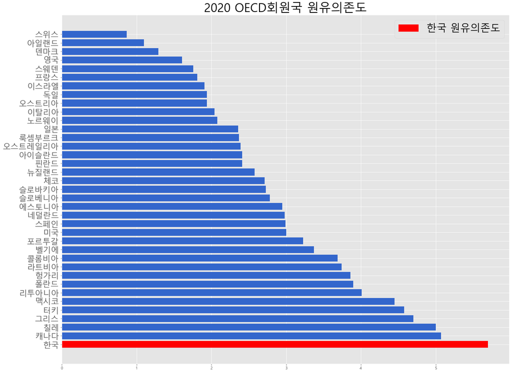

```python
# 원유 의존도 그래프로 시각화
# (1) '국가' index를 x축으로 사용하기 위해 list화
x = oil_DependenceDF.index.to_list()

# (2) 각각의 column들을 y축으로 사용하기 위해 list화
y_1 = oil_DependenceDF['원유의존도(배럴/GDP만달러)'].to_list()

# (3) 그래프로 시각화
if platform.system() == 'Windows':
    plt.rc('font', family='Malgun Gothic')
else:
    plt.rc('font', family='AppleGothic')
plt.figure(figsize=(20,16))
plt.title('2020 OECD회원국 원유의존도', size=30)
colors = ['red']
for i in range(36):
    colors.append('#3366CC')

plt.barh(x,y_1,color = colors, label='한국 원유의존도')
plt.yticks(ticks=x, labels=x, rotation=0, size=20)
plt.legend(fontsize=25)
plt.style.use('ggplot')
plt.show()
```

### 분석

- 2020년 기준 한국은 OECD회원국 37개국 중 1위를 기록하고 있음. 산유국도 아닐뿐더러 중공업의 산업 비중이 높은 우리나라의 특성상 경쟁국인 미국, 일본, 독일, 영국 등에 비해 원유의존도가 높을수 밖에 없다

## (4) 원유 가격 상승에 대한 악영향을 받은 국내 기업 분석

- 유가 민감업종을 중심으로 분석해 보았음
- 부문 : 석유화학, 반도체, 섬유, 철강, 자동차

```python
# exel에서 원하는 sheet읽어서 원하는 데이터만 뽑아오는 함수 생성
# 매출, 영업이익 추출 후 영업이익률 계산
# 영업이익률 = 영업이익 / 총매출
def read_exel_data(file_name):
    dataDF = pd.read_excel(DIR_PATH+file_name, sheet_name='손익계산서', header=6)
    sales_price = dataDF['3개월'].iloc[0]
    sales_profit = dataDF['3개월'].iloc[4]
    profit_margin = sales_profit / sales_price
    return profit_margin

def read_exel_data2(file_name):
    dataDF = pd.read_excel(DIR_PATH+file_name, sheet_name='포괄손익계산서', header=6)
    sales_price = dataDF['3개월'].iloc[0]
    sales_profit = dataDF['3개월'].iloc[4]
    profit_margin = sales_profit / sales_price
    return profit_margin
```

```python
# 회사별 그래프 시각화 함수 생성
def company_graph(company, company_data, field, color):
    if platform.system() == 'Windows':
        plt.rc('font', family='Malgun Gothic')
    else:
        plt.rc('font', family='AppleGothic')
    title = company + ' 영업이익률' + ' [' + field + ']'
    plt.figure(figsize=(20,7))
    plt.title(title, size=30)
    colors = ['#3366CC','#333333','#FF6666']
    plt.plot(date_list,company_data, color=colors[color], label='영업이익률', marker='o', markersize=10, linestyle='--', linewidth=2.0)
    plt.xticks(ticks=date_list, labels=date_list, size=15)
    plt.legend(fontsize=25)
    plt.style.use('ggplot')
    plt.show()
```

## 롯데케미컬[석유화학]

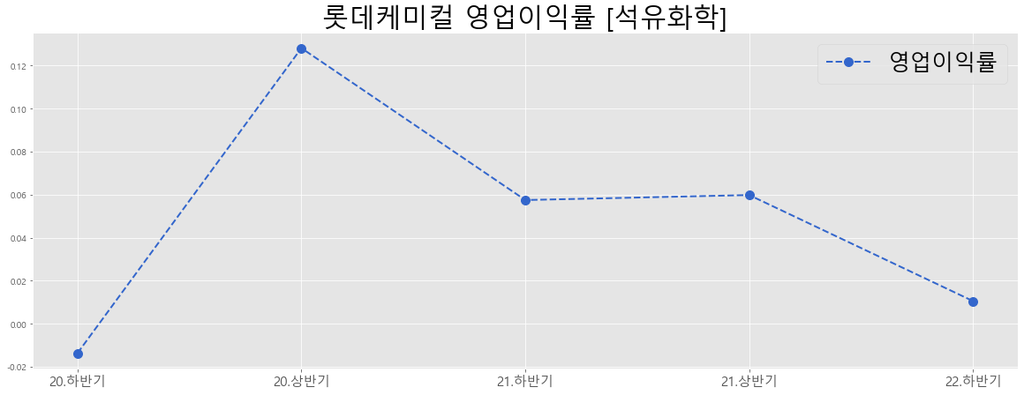

```python
# (1) 롯데케미칼 데이터 list화
date_list = ['20.하반기','20.상반기','21.하반기','21.상반기','22.하반기']
lotte_profit = []
for i in range(1,6):
    file_name = '롯데케미칼' + str(i) + '.xls'
    lotte_profit.append(read_exel_data2(file_name))

# (2) 롯데케미칼 영업이익률 그래프로 시각화
company_graph('롯데케미컬', lotte_profit, '석유화학', 0)
```

## SK하이닉스[반도체]

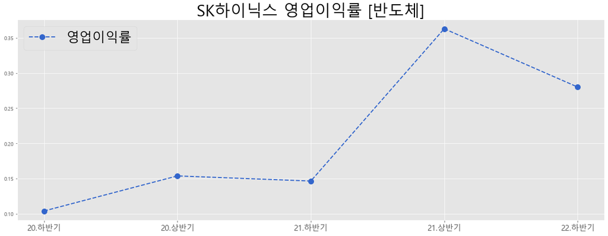

```python
# (1) 하이닉스 데이터 list화
sk_profit = []
for i in range(1,6):
    file_name = 'SK하이닉스' + str(i) + '.xls'
    sk_profit.append(read_exel_data2(file_name))

# (2) 하이닉스 영업이익률 그래프로 시각화
company_graph('SK하이닉스', sk_profit, '반도체', 0)
```

## 코오롱[섬유산업]

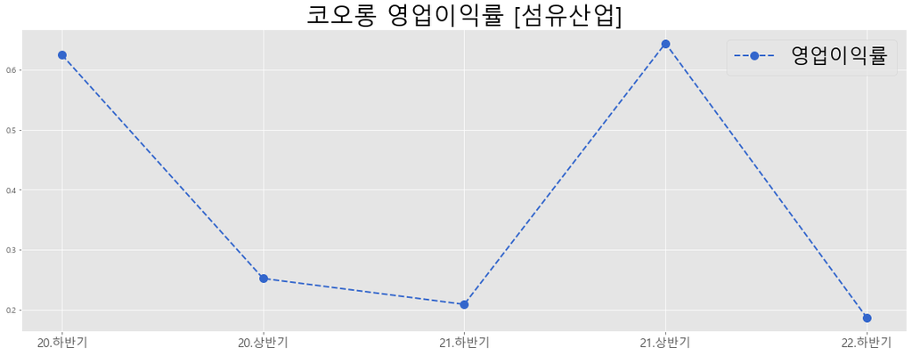

```python
# (1) 코오롱 데이터 list화
ko_profit = []
for i in range(1,6):
    file_name = '코오롱'+ str(i) + '.xls'
    ko_profit.append(read_exel_data2(file_name))

# (2) 코오롱 영업이익률 그래프로 시각화
company_graph('코오롱', ko_profit, '섬유산업', 0)
```

## 현대제철[철강]

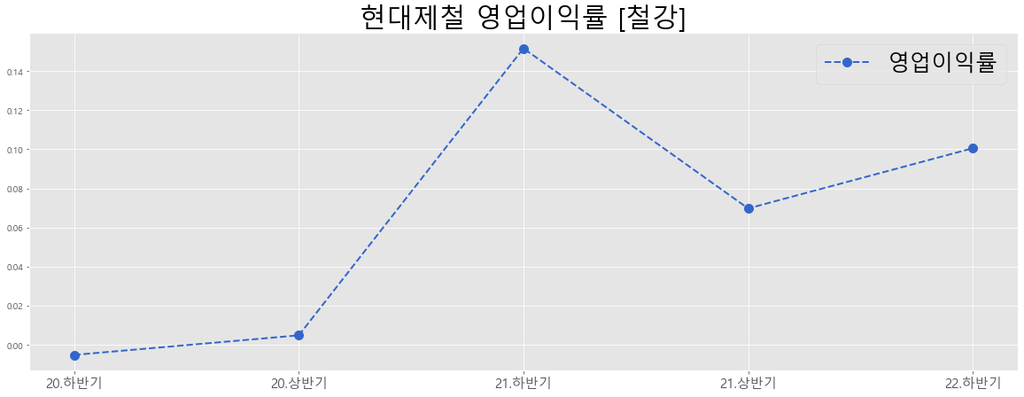

```python
# (1) 현대제철 데이터 list화
hyundai_profit = []
for i in range(1,6):
    file_name = '현대제철' + str(i) + '.xls'
    hyundai_profit.append(read_exel_data2(file_name))

# (2) 현대제철 영업이익률 그래프로 시각화
company_graph('현대제철', hyundai_profit, '철강', 0)
```

## 현대자동차[자동차]

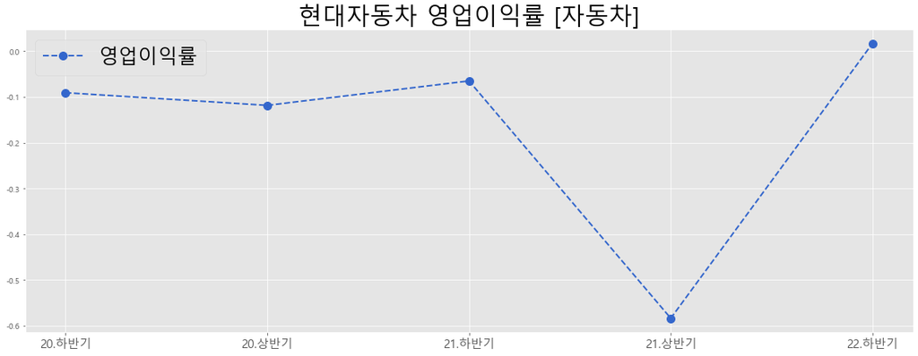

```python
# (1) 현대자동차 데이터 list화
hyundai_car_profit = []
for i in range(1,6):
    file_name = '현대자동차'+ str(i) + '.xls'
    hyundai_car_profit.append(read_exel_data2(file_name))

# (2) 현대자동차 영업이익률 그래프로 시각화
company_graph('현대자동차', hyundai_car_profit, '자동차', 0)
```

## 유가 민감업종 영업이익률 종합

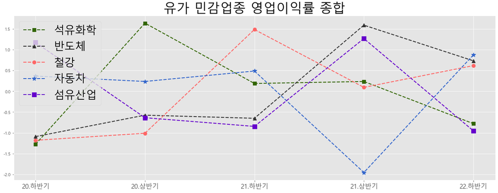

```python
# 종합 비교를 위한 데이터 정규화 작업(standard scale) 모듈 로딩
from sklearn.preprocessing import StandardScaler

# (1) Dataframe으로 종합
all_data = pd.DataFrame([lotte_profit, sk_profit, hyundai_profit, hyundai_car_profit, ko_profit]).T
all_data.columns = ['석유화학','반도체','철강','자동차','섬유산업']

# (2) 정규화 함수 생성
def nomalization(DF_name, col_name):
    sdscaler = StandardScaler()
    sdscaler.fit(DF_name[[col_name]])
    result = sdscaler.transform(DF_name[[col_name]])
    return result

# (3) 그래프로 시각화
if platform.system() == 'Windows':
    plt.rc('font', family='Malgun Gothic')
else:
    plt.rc('font', family='AppleGothic')
plt.figure(figsize=(20,7))
plt.title('유가 민감업종 영업이익률 종합', size=30)
colors = ['#3366CC','#FF6666','#333333','#336600', '#6600CC']
plt.plot(date_list,nomalization(all_data, '석유화학'), color=colors[3], label='석유화학', marker='s', markersize=8, linestyle='--', linewidth=2.0)
plt.plot(date_list,nomalization(all_data, '반도체'), color=colors[2], label='반도체', marker='^', markersize=8, linestyle='--', linewidth=2.0)
plt.plot(date_list,nomalization(all_data, '철강'), color=colors[1], label='철강', marker='o', markersize=8, linestyle='--', linewidth=2.0)
plt.plot(date_list,nomalization(all_data, '자동차'), color=colors[0], label='자동차', marker='*', markersize=10, linestyle='--', linewidth=2.0)
plt.plot(date_list,nomalization(all_data, '섬유산업'), color=colors[4], label='섬유산업', marker='s', markersize=10, linestyle='--', linewidth=2.0)

plt.xticks(ticks=date_list, labels=date_list, size=15)
plt.legend(fontsize=25, loc=2)
plt.style.use('ggplot')
plt.show()
```

### 분석 : 석유 의존도가 높은 산업에서 유가상승으로 인한 영업 이익률 하락세를 보이는 분야가 있었음

- 석유화학 : 기초원료인 원유가격 폭등으로 채산성 악화가 불가피함
- 반도체 : 유가상승으로 인한 국제수급동향이 소극적으로 변화하면서 매출에 영향을 준것으로 보임
- 섬유산업 : 석유화학과 마찬가지로 섬유의 원료 대부분이 원유에서 추출되므로 채산성 악화가 불가피함
- 철강, 자동차 : 예상보다는 유가상승으로 인한 영업이익률의 하락은 보이지 않았으나, 22년 상반기의 재무제표 데이터가 없어서 섣불리 판단할 수 없음

## (5) 원유 가격 상승에 대한 좋은 영향을 받은 국내 기업 분석

- 부문 : 조선(해양플랜트)
  - 해양플랜트란? 바다위에 설치하여 천연가스, 석유 등의 천연자원을 뽑아내는 일련의 구조물

## 삼성중공업[조선]

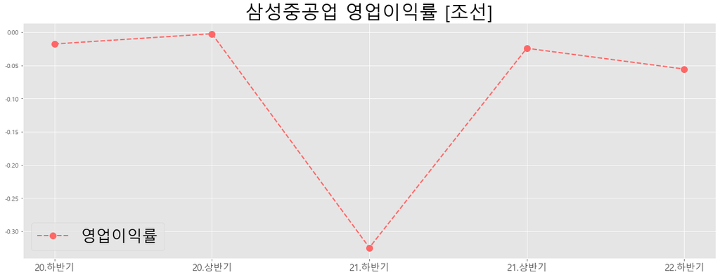

```python
# (1) 삼성중공업 데이터 list화
samsung_profit = []
for i in range(1,6):
    file_name = '삼성중공업'+ str(i) + '.xls'
    samsung_profit.append(read_exel_data(file_name))

# (2) 삼성중공업 영업이익률 그래프로 시각화
company_graph('삼성중공업', samsung_profit, '조선', 2)
```

### 하반기 재무제표에는 나오지 않았지만, 5월에 2차례, 6월에 1차례 각각 5천억 규모의 LNG운반선 수주를 받은것으로 확인함

## 대우조선해양[조선]

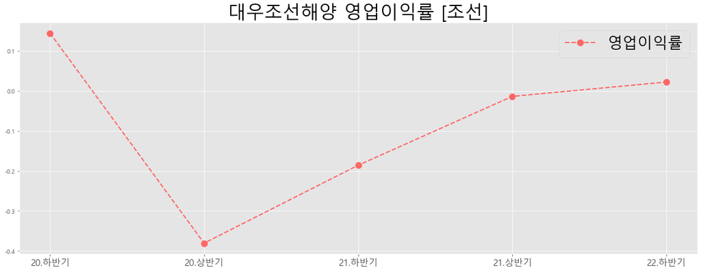

```python
# (1) 대우조선해양 데이터 list화
daewoo_profit = []
for i in range(1,6):
    file_name = '대우조선해양'+ str(i) + '.xls'
    daewoo_profit.append(read_exel_data(file_name))

# (2) 대우조선해양 영업이익률 그래프로 시각화
company_graph('대우조선해양', daewoo_profit, '조선', 2)
```

## (7) 데이터 출처

- 2020.01~2022.07 국제 석유제품 가격(월간) : https://www.opinet.co.kr/glopcoilSelect.do
- 2020.01~2022.07 국내 석유제품 가격(월간) : https://www.opinet.co.kr/user/dopospdrg/dopOsPdrgAreaView.do
- 원유 의존도 : http://hri.co.kr/board/reportView.asp?numIdx=30296&firstDepth=1&secondDepth=1
- 각종 기업들 재무제표 : https://dart.fss.or.kr/